# Homework 10

Tyler Sousa

2026-02-11

## Instructions

Answer the following questions and complete the exercises in RMarkdown. Please embed all of your code and push your final work to your repository. Your final lab report should be organized, clean, and run free from errors. Remember, you must remove the `#` for the included code chunks to run. Be sure to add your name to the author header above.

Make sure to use the formatting conventions of RMarkdown to make your report neat and clean!

## Background

In the `data` folder, you will find data about shark incidents in California between 1950-2022. The [data](https://catalog.data.gov/dataset/shark-incident-database-california-56167) are from: State of California- Shark Incident Database.

## Load the libraries

```r
library("tidyverse")
library("janitor")
```

## Load the data

Run the following code chunk to import the data. In this chunk, I am removing NA’s.

```r
sharks <-
  read_csv("data/SharkIncidents_1950_2022_220302.csv",
           na=c("NA", "N/A", "Unknown", "NOT COUNTED", "", " ")) %>%
  clean_names()
```

## Questions

1. Are there any “hotspots” for shark incidents in California? Show the top five counties with the most incidents.

```r
sharks %>%
  group_by(county) %>%
  summarize(total=n()) %>%
  arrange(desc(total)) %>%
  head(n=5)
```

```
## # A tibble: 5 × 2
##   county        total
##   <chr>         <int>
## 1 San Diego        25
## 2 Humboldt         20
## 3 San Mateo        19
## 4 Santa Barbara    19
## 5 Marin            16
```

2. Make a plot that shows the total number of incidents per county.

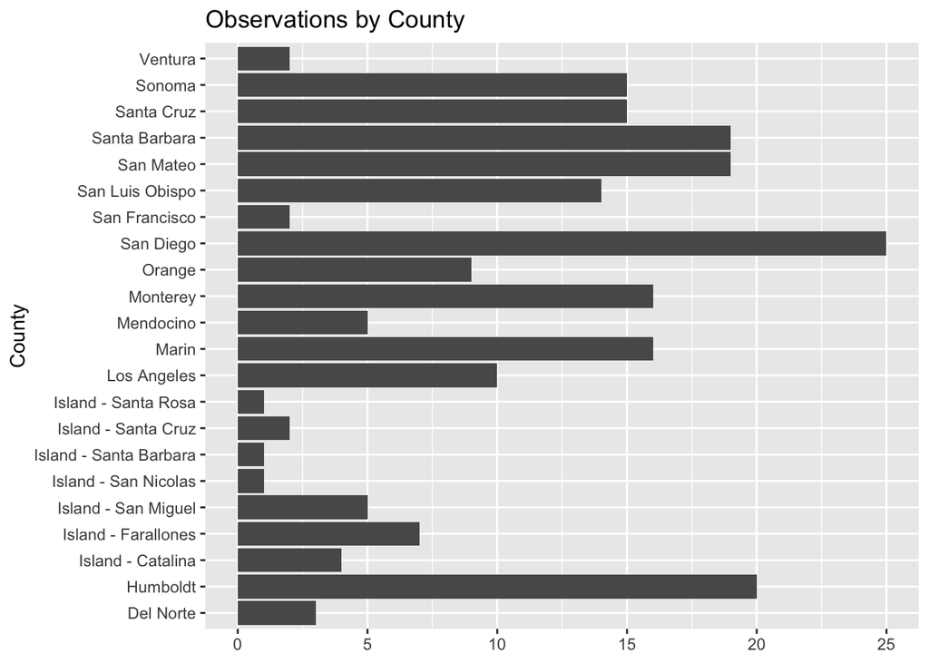

```r
sharks %>%
  ggplot(aes(x=county))+
  geom_bar()+
  coord_flip()+
  labs(title="Observations by County",
       x="County",
       y=NULL)
```

3. Are there months of the year when incidents are more likely to occur? Make a plot that shows the total number of incidents by month. Which month has the highest number of incidents?

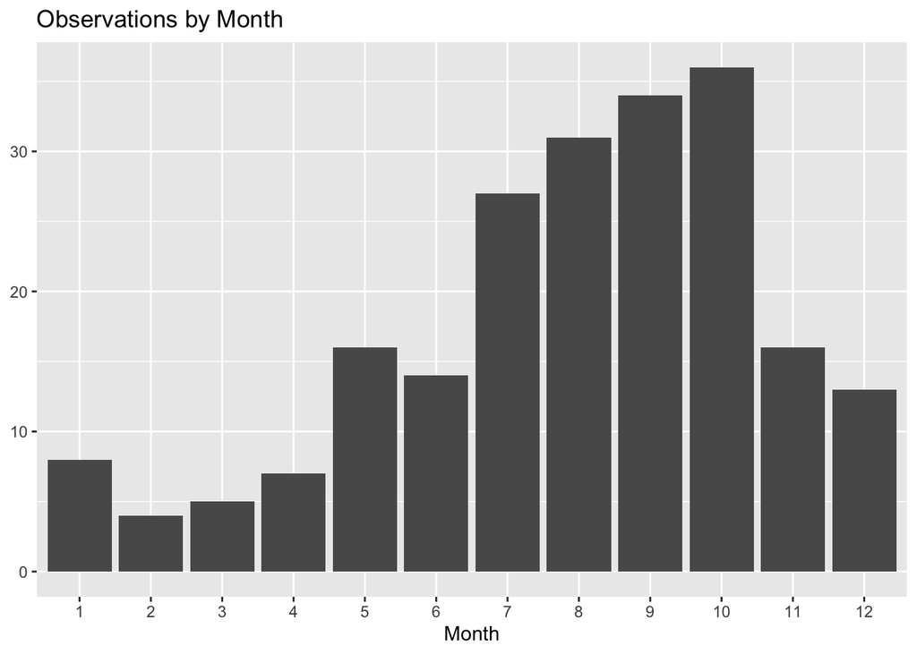

```r
sharks %>%
  mutate(across(month, as.factor)) %>%
  ggplot(aes(x=month))+
  geom_bar()+
  labs(title="Observations by Month",
       x="Month",
       y=NULL)
```

4. Is there a time of day when most attacks occur? Make a plot that shows the total number of incidents by time of day. Which time of day has the highest number of incidents?

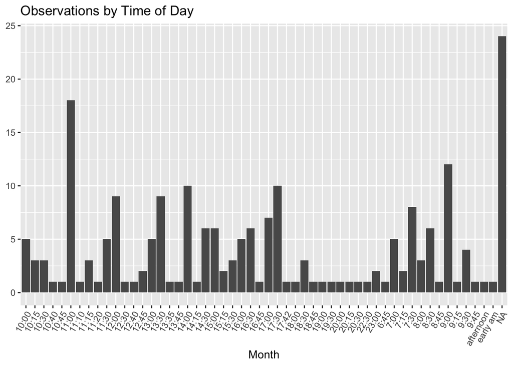

```r
sharks %>%
  ggplot(aes(x=time))+
  geom_bar()+
  theme(axis.text.x=element_text(angle=60, hjust=1))+
  labs(title="Observations by Time of Day",
       x="Month",
       y=NULL)
```

11 am had the most number of incidents.

5. How do the number and types of injuries compare by county? Make a table that shows the number of injury types by county. Which county has the highest number incidents? (hint: your table should be in wide format)

I am not sure if I am interpreting the question correctly. My first instinct was to do the code chunk below, but I could not figure out how this could be easily pivoted to wide format while using both the n and number_of_injury_types_by_county columns.

```r
sharks %>%
  group_by(county) %>%
  summarize(number_of_injury_types_by_county=n_distinct(injury), n=n()) %>%
  arrange(desc(number_of_injury_types_by_county))
```

```
## # A tibble: 22 × 3
##    county              number_of_injury_types_by_county     n
##    <chr>                                          <int> <int>
##  1 San Diego                                          6    25
##  2 Humboldt                                           5    20
##  3 Monterey                                           5    16
##  4 San Mateo                                          5    19
##  5 Los Angeles                                        4    10
##  6 Orange                                             4     9
##  7 San Luis Obispo                                    4    14
##  8 Santa Barbara                                      4    19
##  9 Santa Cruz                                         4    15
## 10 Island - San Miguel                                3     5
## # ℹ 12 more rows
```

Because the question says to make a table that shows the number of injury types by county, this is what I did, even though I cannot answer with county has the highest number of incidents with it.

```r
sharks %>%
  group_by(county) %>%
  summarize(number_of_injury_types_by_county=n_distinct(injury)) %>%
  arrange(desc(number_of_injury_types_by_county)) %>%
  pivot_wider(names_from = "county",
              values_from = "number_of_injury_types_by_county")
```

```
## # A tibble: 1 × 22
##   `San Diego` Humboldt Monterey `San Mateo` `Los Angeles` Orange
##         <int>    <int>    <int>       <int>         <int>  <int>
## 1           6        5        5           5             4      4
## # ℹ 16 more variables: `San Luis Obispo` <int>, `Santa Barbara` <int>,
## #   `Santa Cruz` <int>, `Island - San Miguel` <int>, Marin <int>,
## #   Mendocino <int>, Sonoma <int>, `Del Norte` <int>,
## #   `Island - Catalina` <int>, `Island - Santa Cruz` <int>,
## #   `San Francisco` <int>, `Island - Farallones` <int>,
## #   `Island - San Nicolas` <int>, `Island - Santa Barbara` <int>,
## #   `Island - Santa Rosa` <int>, Ventura <int>
```

But because question 6 asks to use the table with the total number of incidents by county, I did it this way. I am probably just missing something but right now I don’t know what it is.

```r
sharks %>%
  group_by(county) %>%
  summarize(n=n()) %>%
  pivot_wider(names_from = "county",
              values_from = "n")
```

```
## # A tibble: 1 × 22
##   `Del Norte` Humboldt `Island - Catalina` `Island - Farallones`
##         <int>    <int>               <int>                 <int>
## 1           3       20                   4                     7
## # ℹ 18 more variables: `Island - San Miguel` <int>,
## #   `Island - San Nicolas` <int>, `Island - Santa Barbara` <int>,
## #   `Island - Santa Cruz` <int>, `Island - Santa Rosa` <int>,
## #   `Los Angeles` <int>, Marin <int>, Mendocino <int>, Monterey <int>,
## #   Orange <int>, `San Diego` <int>, `San Francisco` <int>,
## #   `San Luis Obispo` <int>, `San Mateo` <int>, `Santa Barbara` <int>,
## #   `Santa Cruz` <int>, Sonoma <int>, Ventura <int>
```

After going back over it after finishing the hw, I came up with this, which I think maybe answers the question. I am not sure, I’m going to leave all of this rambling in and also just ask in class :)

```r
table <- sharks %>%
  group_by(county, injury) %>%
  summarize(n=n()) %>%
  pivot_wider(names_from = county,
              values_from = n,)
table
```

```
## # A tibble: 7 × 23
##   injury `Del Norte` Humboldt `Island - Catalina` `Island - Farallones`
##   <chr>        <int>    <int>               <int>                 <int>
## 1 minor            2        2                   1                    NA
## 2 none             1        9                   3                    NA
## 3 major           NA        7                  NA                     7
## 4 minor*          NA        1                  NA                    NA
## 5 none*           NA        1                  NA                    NA
## 6 fatal           NA       NA                  NA                    NA
## 7 major*          NA       NA                  NA                    NA
## # ℹ 18 more variables: `Island - San Miguel` <int>,
## #   `Island - San Nicolas` <int>, `Island - Santa Barbara` <int>,
## #   `Island - Santa Cruz` <int>, `Island - Santa Rosa` <int>,
## #   `Los Angeles` <int>, Marin <int>, Mendocino <int>, Monterey <int>,
## #   Orange <int>, `San Diego` <int>, `San Francisco` <int>,
## #   `San Luis Obispo` <int>, `San Mateo` <int>, `Santa Barbara` <int>,
## #   `Santa Cruz` <int>, Sonoma <int>, Ventura <int>
```

San Diego has the highest number of incidents.

6. Use the table from #5 to make a plot that shows the total number of incidents by county.

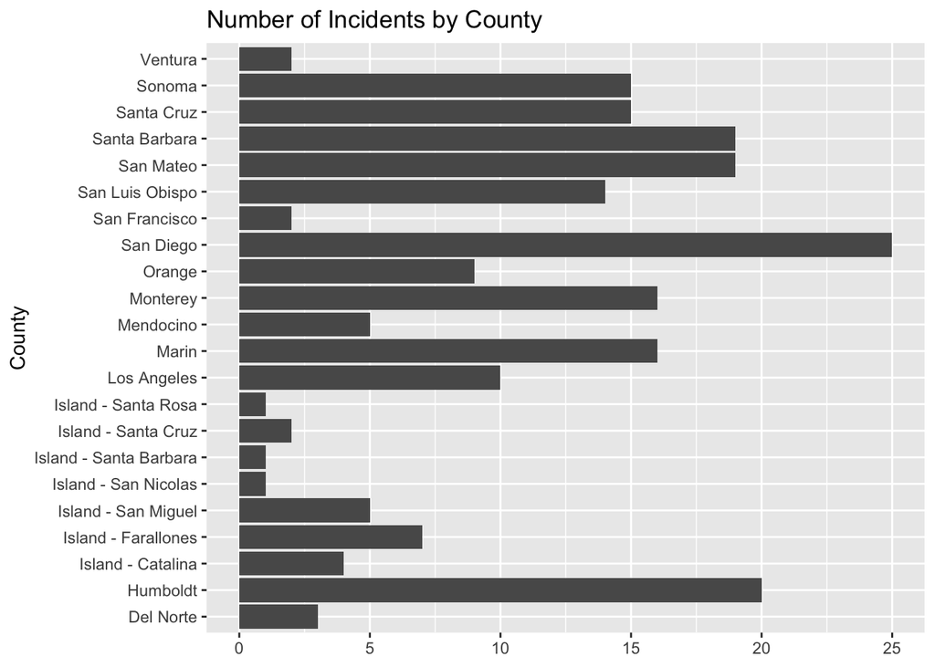

```r
table %>%
  pivot_longer(-injury,
               names_to = "county",
               values_to = "n_incidents") %>%
  group_by(county) %>%
  summarize(n_incidents=sum(n_incidents, na.rm=T)) %>%
  ggplot(aes(x=county, y=n_incidents))+
  geom_col()+
  coord_flip()+
  labs(title="Number of Incidents by County",
       x="County",
       y=NULL)
```

7. In the data, `mode` refers to a type of activity. Which activity is associated with the highest number of incidents?

```r
sharks %>%
  group_by(mode) %>%
  summarize(n=n()) %>%
  arrange(desc(n))
```

```
## # A tibble: 8 × 2
##   mode                    n
##   <chr>               <int>
## 1 Surfing / Boarding     85
## 2 Freediving             36
## 3 Kayaking / Canoeing    30
## 4 Swimming               22
## 5 Scuba Diving           20
## 6 Hookah Diving          10
## 7 Paddleboarding          7
## 8 Walking in shallow      1
```

Surfing/boarding is associated with the highest number of incidents.

8. Make a plot that compares the number of incidents by activity.

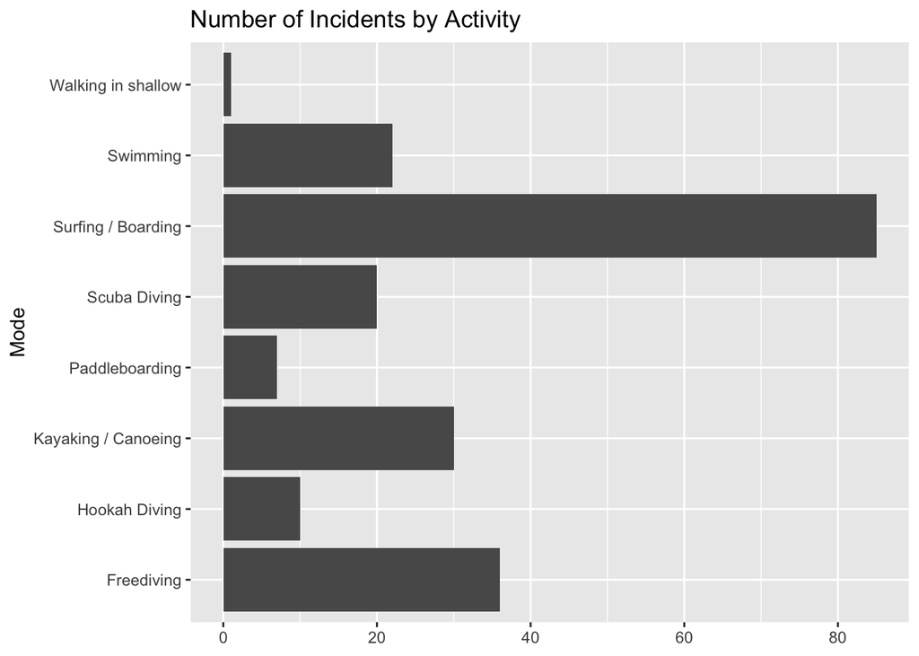

```r
sharks %>%
  ggplot(aes(x=mode))+
  geom_bar()+
  coord_flip()+
  labs(title="Number of Incidents by Activity",
       x="Mode",
       y=NULL)
```

9. Which shark species is involved in the highest number of incidents?

```r
sharks %>%
  group_by(species) %>%
  summarise(n=n()) %>%
  arrange(desc(n))
```

```
## # A tibble: 12 × 2
##    species          n
##    <chr>        <int>
##  1 White          181
##  2 <NA>            14
##  3 Hammerhead       3
##  4 Blue             2
##  5 Killer Whale     2
##  6 Leopard          2
##  7 Salmon           2
##  8 Blue*            1
##  9 Mako             1
## 10 Sevengill        1
## 11 Thresher         1
## 12 blue             1
```

Great white sharks are involved in the highest number of incidents.

10. Are all incidents involving Great White’s fatal? Make a plot that shows the number and types of incidents for Great White’s only.

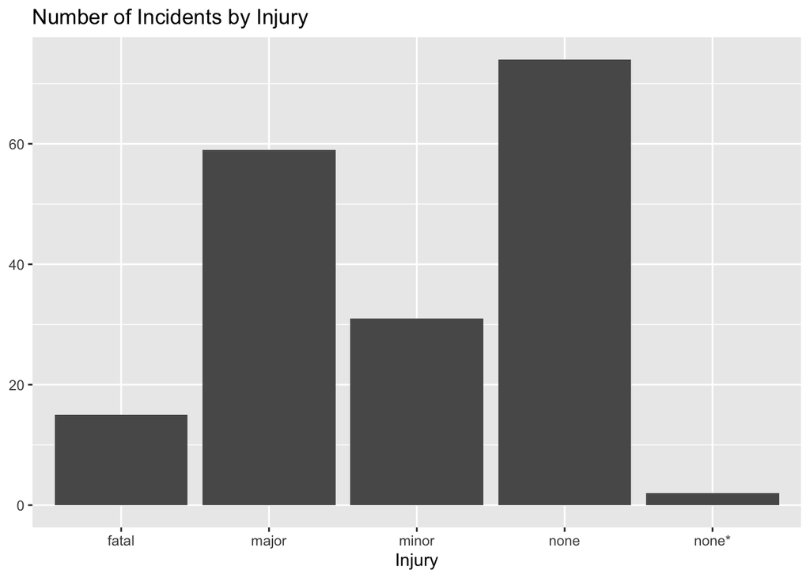

```r
sharks %>%
  filter(species=="White") %>%
  ggplot(aes(x=injury))+
  geom_bar()+
  labs(title="Number of Incidents by Injury",
       y=NULL,
       x="Injury")
```

## Knit and Upload

Please knit your work as an .html file and upload to Canvas. Homework is due before the start of the next lab. No late work is accepted. Make sure to use the formatting conventions of RMarkdown to make your report neat and clean!